# Daynamica Activity Chains Example

Daynamica Team

2025-01-02

```r
library(dplyr)
library(ggplot2)

source('../helper_functions/s11_activity_chains_helper_functions.R')

knitr::opts_chunk$set(echo = TRUE, fig.width = 12, fig.height = 8, message = F, warning = F)
```

# Overview

This report serves as a tutorial on how to generate and analyze **Activity Chains** within a Daynamica dataset. The primary input to the analysis is the calendar items dataset (ucalitems_temporal_plot). Because this report is meant to serve as a code tutorial, the code used to generate the report will be displayed throughout. The code may be hidden via the grey “Code” button in the top right corner. For specific details on the functions used in this tutorial, see “helper_functions/s11_activity_chains_helper_functions.R”.

Activity Chains are defined as a sequential string of activities and trips that a person engages in throughout the day. The algorithm for constructing the chain is as follows.

Algorithm:

1.Group data by Person:Day

2. Per Person:Day, sort by Calendar Item start time
3. Filter all activities and trips less than X minutes where X is an input.
4. Relabel Activities and Trips into single letter variables*
5. Reduced duplicated labels (e.g. HOOWH -> HOWH). This feature may be turned off if desired.
- **Note**: The function allows for special labeling of specific activity types. It defaults to labeling Home - “H”, Workplace / Work - “W” and all other activities as “O”. Trips are labeled as “T”. The function allows for new subtypes to get additional labels.

# Creating Acitivity Chains

To create the activity chains, use the function `create_activity_chains`. The specific arguments are dataset, include_trips (T/F), minimum duration_min (see step 3), special_labels_long and special_labels_short (see step 4), and collapse_identical_labels (T/F) (See Step 5).

```r
library(networkD3)
library(dplyr)
library(stringr)
library(tidyr)
library(webshot)
library(lubridate)
```

## Including / Excluding Trips

```r
csv_dict_sub <- params$daynamica_data
create_activity_chains(csv_dict_sub$ucalitems_temporal_plot,
                       include_trips = T,
                       minimum_duration_min = 15) %>%
  head()
```

```
## # A tibble: 6 x 3
## # Groups:   user_id [1]
##   user_id     start_date string
##   <chr>       <date>     <chr>
## 1 user_id_122 2022-11-16 OO
## 2 user_id_122 2022-11-17 OOOTTTO
## 3 user_id_122 2022-11-18 OOO
## 4 user_id_122 2022-11-20 OHH
## 5 user_id_122 2022-11-21 HOOH
## 6 user_id_122 2022-11-22 HTOOO
```

```r
create_activity_chains(csv_dict_sub$ucalitems_temporal_plot,
                       include_trips = F,
                       minimum_duration_min = 15) %>%
  head()
```

```
## # A tibble: 6 x 3
## # Groups:   user_id [1]
##   user_id     start_date string
##   <chr>       <date>     <chr>
## 1 user_id_122 2022-11-16 OO
## 2 user_id_122 2022-11-17 OOOO
## 3 user_id_122 2022-11-18 OOO
## 4 user_id_122 2022-11-20 OHH
## 5 user_id_122 2022-11-21 HOOH
## 6 user_id_122 2022-11-22 HOOO
```

## Adding New Labels

In this example, we add a new label for “Food & Meal” called “F”.

```r
create_activity_chains(csv_dict_sub$ucalitems_temporal_plot,
                       include_trips = T,
                       special_labels_long = c("HOME", "WORKPLACE", "WORK"),
                       special_labels_short = c("H", "W", "W"),
                       minimum_duration_min = 15,
                       collapse_identical_labels = T)  %>%
  pull(string) %>% table() %>% sort()
```

```
## .
##  HOHTWH   HOHWH  HOTHOH  HOTHWH    HOTO   HOTOH   HOTOT   HOTWO  HOWTOH      HT
##       1       1       1       1       1       1       1       1       1       1
##  HTHOTH   HTHWH   HTHWO  HTOHOH  HTOHWH   HTOTO HTOTOTH  HTOWOH  HTOWTO     HTW
##       1       1       1       1       1       1       1       1       1       1
##  HTWHTH   HTWOH  HTWOTH  HTWTOW   HTWTW  HWOTOW  HWTHTH   HWTOW    OHTO    OHTW
##       1       1       1       1       1       1       1       1       1       1
##    OHWH  OHWHOH    OTOT   OTOTO   OTOWH     OTW    OTWH    OWHO   OWOTH  OWTHTO
##       1       1       1       1       1       1       1       1       1       1
##    OWTO      TH     THO      TO   TOTOW     TWH     TWO     WHO    WHOH   WHTHT
##       1       1       1       1       1       1       1       1       1       1
##    WOTO   WTHWH   WTOTO    WTWH   WTWTO    HOHW     HOT   HOTWH     HOW   HOWOH
##       1       1       1       1       1       2       2       2       2       2
##   HTHOH   HTHTH    HTHW   HTOTH  HTWHOH    HTWO   HTWTH   HWHTH     HWT   HWTWH
##       2       2       2       2       2       2       2       2       2       2
##   OHOHO      OT    OTWO     OWH     OWO     WTH     WTO     WTW   HOHTH      HW
##       2       2       2       2       2       2       2       2       3       3
##     OHO    OHOH     OTH    OTHO     TOH     WHW      WO    WOHO     WOW   HWHOH
##       3       3       3       3       3       3       3       3       3       4
##      OW       W    HOHO    OHTH    HOWH      WH   HOHOH     HTO    HWOH    HTOH
##       4       4       5       5       6       6       8       8       8       9
##    HTWH      HO    HOTH    HWTH      OH     OTO     HTH     HWH       O     HOH
##      11      13      13      13      16      18      24      39      65      71
##       H
##     115
```

```r
create_activity_chains(csv_dict_sub$ucalitems_temporal_plot,
                       include_trips = F,
                       special_labels_long = c("HOME", "WORKPLACE", "WORK", "FOOD & MEAL"),
                       special_labels_short = c("H", "W", "W", "F"),
                       minimum_duration_min = 15,
                       collapse_identical_labels = T) %>%
  pull(string) %>% table() %>% sort()
```

```
## .
##    FHO   FHOH    FOH    FOW  HFHOH  HFOFH  HFWFH  HFWOH   HOFO  HOFOH  HOHOF
##      1      1      1      1      1      1      1      1      1      1      1
##  HWHFH    HWO  OFOWH    OHF  OHOFO OHOHFO  OHOHO    OHW   OHWH OHWHFH   OWOH
##      1      1      1      1      1      1      1      1      1      1      1
##    WHO   WHOH   WHWH     FO    FOF   HOFH   HOHW    HOW   HOWO  HOWOH    HWF
##      1      1      1      2      2      2      2      2      2      2      2
##     OF    OFH   OFOH   OHOH   OWHO   HWOW    OWH    WHW   WOHO    WOW    HFH
##      2      2      2      2      2      3      3      3      3      3      4
##   HFOH   HOHO  HOHWH   HWFH    OFO    OHO  HWHOH     OW    OWO   HWOH      W
##      4      4      4      4      4      4      5      5      5      6      6
##   HOWH  HOHOH     HW     WO     WH     OH     HO    HWH      O    HOH      H
##      8      9      9      9     11     22     26     72     78     91    143
```

# Summarizing Activity Chains

## Creating a conditional Activity Chains summary

In this section, we show how to create an conditional summary table. This is created via the function `create_sankey_data`. This function generates a table showing the number of activity chains that have chains whose start matches a specific string pattern (e.g. HOH).

- prev: Previous Activity Chain String
- current: Current Activity Chain label
- count: Number of Activity Chains in this dataset that match prev + current
- group_precentage: Of the Activity Chains that match the prev Activity String, what proportion have the current Activity Chain label.

For example we might have the following dataset.

```r
activity_chains_data <-
  create_activity_chains(csv_dict_sub$ucalitems_temporal_plot,
                         include_trips = T,
                         minimum_duration_min = 15, collapse_identical_labels = T)
create_sankey_data(activity_chains_data, lower_limit = 0.01)[1,]
```

```
##   prev current count group_percentage
## 1            H   411              69%
```

In this case, prev = ““, so all Activity Chains apply. For all applicable Activity Chains, 411 Chains had a first activity as”H”, of all Activity Chains, 411 represented 69% of that population.

In another example, we have prev = “HO”, so we are only interested in Chains that start with “HO”. Because current = “T”, we are interested in ACtivity Chains that start with or are “HOT”. There are 23 matching that description, and they represent 17% of all chains that start with “HO”.

```r
create_sankey_data(activity_chains_data, lower_limit = 0.01)[10,]
```

```
##    prev current count group_percentage
## 10   HO       T    23              17%
```

It should be noted that when current = “X” it represents a terminated string. So in this case, if prev = “H” and current = “X”, we are interested in the count of chains that start with “H” and do not add any additional characters to the chain (so “H” alone). Of the chains starting with “H”, 28% ended with only “H” instead of continuing on.

```r
create_sankey_data(activity_chains_data, lower_limit = 0.01)[8,]
```

```
##   prev current count group_percentage
## 8    H       X   115              28%
```

## Visualizing conditional Activity Chains Summary Tables (Sankey Plots)

Plots can be created using `create_plot_from_data` using the output of `create_sankey_data` directly`. The plot may be modified to only include chains that start with “H”.

This function creates an HTML widget figure which allows for tuning of the figure where you may drag the nodes around to match specific aesthetic preferences. This is at the expense of limited reproducibility in terms of exporting standardized outputs. These plots may be saved via a computer screenshot.

```r
activity_chains_data <-
  create_activity_chains(csv_dict_sub$ucalitems_temporal_plot,
                         include_trips = T,
                         minimum_duration_min = 15, collapse_identical_labels = T)


sankey_data <- create_sankey_data(activity_chains_data, lower_limit = 0.01)
q <- create_plot_from_data(sankey_data, start_from_H = T)
#q


# We may also export a single html document with that plot using htmlwidgets::saveWidget functionality.
#
#htmlwidgets::saveWidget(widget = q,
#                        file = "../outputs/Module 4/temp.html",
#                        selfcontained = TRUE)
```

[interactive chart not shown]

## ggplot2 / ggalluvial alternative visualization

This is an alternative visual style for activity chains which may provide a more standardized format. This visualization may be useful when doing a large number of sub-group analyses which requires frequent generation of these plots.

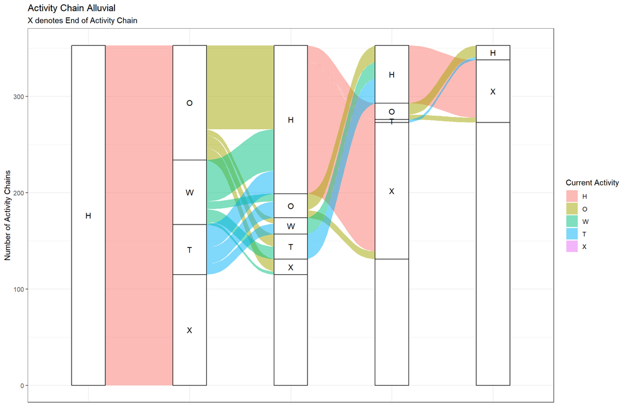

```r
#install.packages("ggalluvial")
library(ggalluvial)

activity_chains_data %>%
  group_by(string) %>%
  dplyr::summarize(n = n()) %>%
  arrange(desc(n)) %>%
  slice_head(n = 30) %>%
mutate(string = paste0(string, "X"),
       first_char = substr(string, 1, 1),
       second_char = substr(string, 2, 2),
       third_char = substr(string, 3, 3),
       fourth_char = substr(string, 4, 4),
       fifth_char = substr(string, 5, 5),
       sixth_char = substr(string, 6, 6),
       seventh_char = substr(string, 7, 7),
       eigth_char = substr(string, 8, 8)) %>%
  filter(first_char == "H") %>%
  to_lodes_form(key = "string", axes = c("first_char", "second_char",
                                         "third_char", "fourth_char",
                                         "fifth_char")) %>%
  mutate(stratum = factor(stratum, levels = c("H", "O", "W", "T", "X"))) %>%
  ggplot(aes(x = string, y = n, stratum = stratum, alluvium = alluvium, label = stratum)) +
  geom_flow(aes(fill = stratum)) +
  geom_stratum() + geom_text(stat = "stratum") +
  theme_bw() +
  ylab("Number of Activity Chains") +
  xlab("") +
  theme(axis.text.x = element_blank(),
        axis.ticks.x = element_blank()) +
  labs(fill = "Current Activity")+
  scale_fill_discrete(na.translate = F) +
  ggtitle("Activity Chain Alluvial",
          "X denotes End of Activity Chain")
```

# Simulating Activity Chains Datasets

We may choose to simulate an activity chains dataset. This is done by the function `run_chain_simulation()`. This function has an arguments for how many person:days should be generated (sim_count) as well as whether the dataset should be exported or whether the dataset should be passed directly into `create_sankey_data` and `create_plot_from_data` via the argument export_data_only.

The simulation is done via a multinomial draw. Proportional to the prevalence rate within the Activity Chains dataset. This means that if the “H” Chain has a 30% prevalence in the dataset, then the simulation assumes there is a 30% chance of drawing an Activity Chain of “H”.

```r
set.seed(1)
run_chain_simulation(activity_chains_data, export_data_only = T, sim_count = 200) %>% # Simulate Dataset (200 Person Days)
  filter(counts != 0) %>% # Filter out Activity Chains not simulated
  uncount(counts) %>% # Data is sumulated in terms of counts. This expands the data to mimic the original Activity Chains dataset
  mutate(string = as.character(Var1)) %>% # Relabel to match destination formatting
  create_sankey_data() %>% # Create Sankey Data
  create_plot_from_data() # Generate Sankey Plot
```

[interactive chart not shown]

```r
set.seed(1)
run_chain_simulation(activity_chains_data, export_data_only = F, sim_count = 200) # If the final outcome is the sankey plot, can generate directly within the function.
```

[interactive chart not shown]

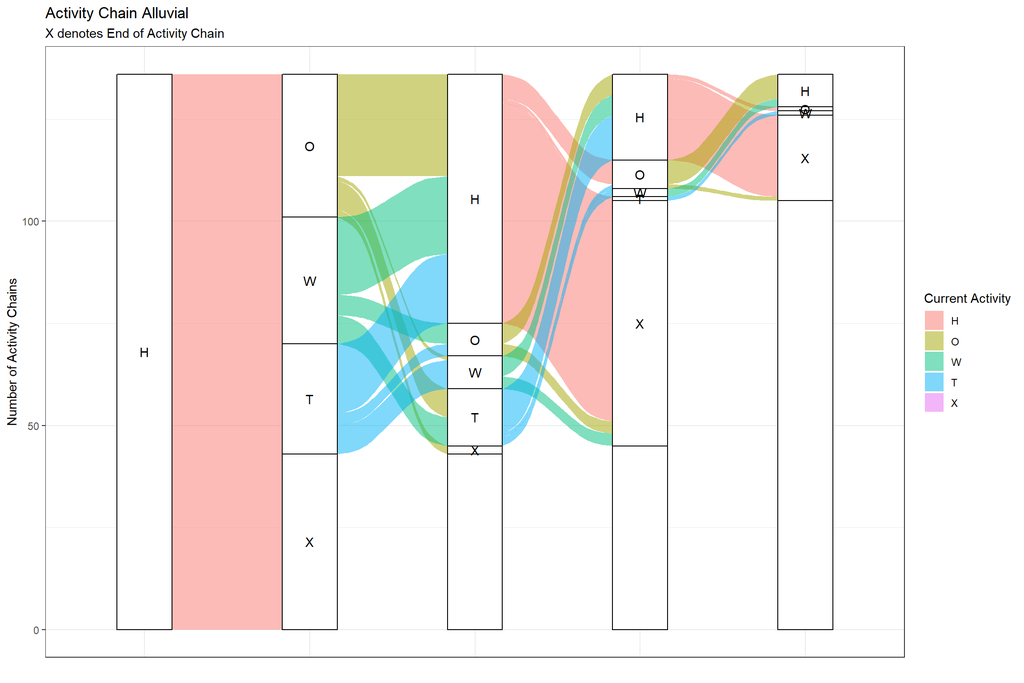

```r
set.seed(1)
run_chain_simulation(activity_chains_data, export_data_only = T, sim_count = 200) %>% # Same simulation, but using the alternative plotting format.
  filter(counts != 0) %>%
  #select(Var1, counts) %>%
  uncount(counts) %>%
  mutate(string = as.character(Var1))%>%
  group_by(string) %>%
  dplyr::summarize(n = n()) %>%
  arrange(desc(n)) %>%
  slice_head(n = 30) %>%
mutate(string = paste0(string, "X"),
       first_char = substr(string, 1, 1),
       second_char = substr(string, 2, 2),
       third_char = substr(string, 3, 3),
       fourth_char = substr(string, 4, 4),
       fifth_char = substr(string, 5, 5),
       sixth_char = substr(string, 6, 6),
       seventh_char = substr(string, 7, 7),
       eigth_char = substr(string, 8, 8)) %>%
  filter(first_char == "H") %>%
  to_lodes_form(key = "string", axes = c("first_char", "second_char",
                                         "third_char", "fourth_char",
                                         "fifth_char")) %>%
  mutate(stratum = factor(stratum, levels = c("H", "O", "W", "T", "X"))) %>%
  ggplot(aes(x = string, y = n, stratum = stratum, alluvium = alluvium, label = stratum)) +
  geom_flow(aes(fill = stratum)) +
  geom_stratum() + geom_text(stat = "stratum") +
  theme_bw() +
  ylab("Number of Activity Chains") +
  xlab("") +
  theme(axis.text.x = element_blank(),
        axis.ticks.x = element_blank()) +
  labs(fill = "Current Activity")+
  scale_fill_discrete(na.translate = F) +
  ggtitle("Activity Chain Alluvial",
          "X denotes End of Activity Chain")
```

# Weekday vs Weekend Example Analysis

Comparing Weekday vs Weekends.

## V1 - Faceting in GGPlot

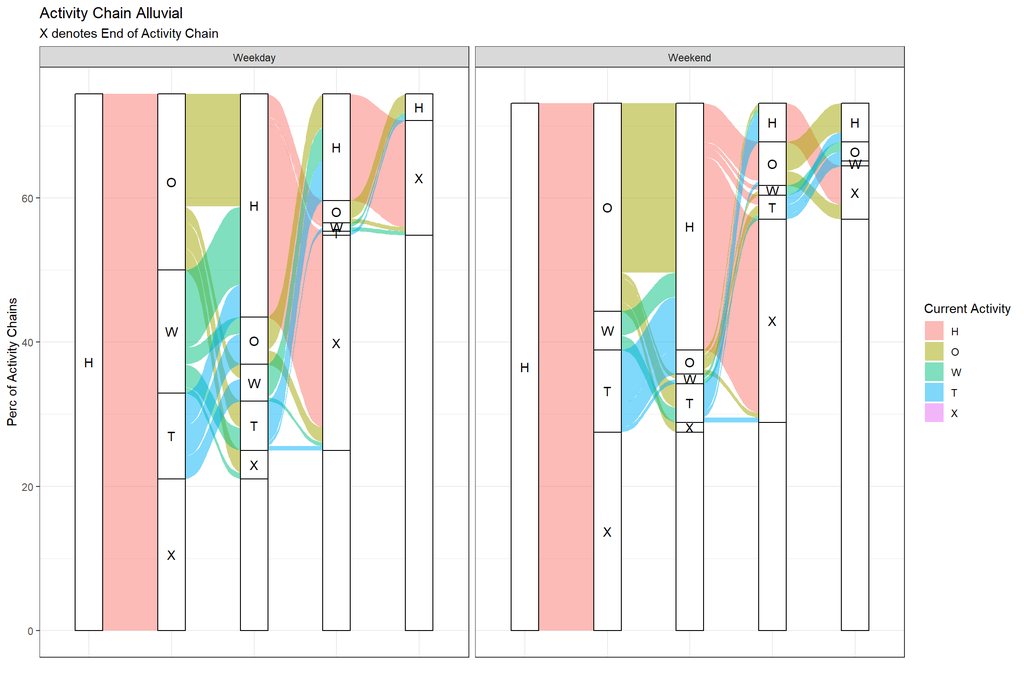

```r
activity_chains_data %>%
  mutate(dow = weekdays(start_date),
         weekend_fac = case_when(dow %in% c("Saturday", "Sunday") ~ "Weekend",
                             TRUE ~ "Weekday")) %>%
  group_by(weekend_fac, string) %>%
  dplyr::summarize(n = n()) %>%
  arrange(desc(n)) %>%
  slice_head(n = 30) %>%
  ungroup() %>%
  #group_by(string) %>%
  dplyr::group_by(weekend_fac) %>%
  #dplyr::summarize(tot_n = sum(n))
  dplyr::mutate(perc = n/sum(n)*100,
         tot_n = sum(n)) %>%
mutate(string = paste0(string, "X"),
       first_char = substr(string, 1, 1),
       second_char = substr(string, 2, 2),
       third_char = substr(string, 3, 3),
       fourth_char = substr(string, 4, 4),
       fifth_char = substr(string, 5, 5),
       sixth_char = substr(string, 6, 6),
       seventh_char = substr(string, 7, 7),
       eigth_char = substr(string, 8, 8)) %>%
  filter(first_char == "H") %>%
  to_lodes_form(key = "string", axes = c("first_char", "second_char",
                                         "third_char", "fourth_char",
                                         "fifth_char")) %>%
  mutate(stratum = factor(stratum, levels = c("H", "O", "W", "T", "X"))) %>%
  ggplot(aes(x = string, y = perc, stratum = stratum, alluvium = alluvium, label = stratum)) +
  geom_flow(aes(fill = stratum)) +
  geom_stratum() + geom_text(stat = "stratum") +
  theme_bw() +
  ylab("Perc of Activity Chains") +
  xlab("") +
  theme(axis.text.x = element_blank(),
        axis.ticks.x = element_blank()) +
  labs(fill = "Current Activity")+
  scale_fill_discrete(na.translate = F) +
  ggtitle("Activity Chain Alluvial",
          "X denotes End of Activity Chain") +
  facet_wrap(~weekend_fac)
```

## V2 - Preprocess data

### Weekday Only

```r
activity_chains_data %>%
  mutate(dow = weekdays(start_date),
         weekend_fac = case_when(dow %in% c("Saturday", "Sunday") ~ "Weekend",
                             TRUE ~ "Weekday")) %>%
  filter(weekend_fac == "Weekday") %>%
  create_sankey_data(lower_limit = 0.02) %>% # Create Sankey Data
  create_plot_from_data()
```

[interactive chart not shown]

### Weekend Only

```r
activity_chains_data %>%
  mutate(dow = weekdays(start_date),
         weekend_fac = case_when(dow %in% c("Saturday", "Sunday") ~ "Weekend",
                             TRUE ~ "Weekday")) %>%
  filter(weekend_fac == "Weekend") %>%
  create_sankey_data(lower_limit = 0.02) %>% # Create Sankey Data
  create_plot_from_data()
```

[interactive chart not shown]